# TIME SERIES FORECASTING - ROSE WINE DATASET

### Problem Statement:

For this particular assignment, the data of different types of wine sales in the 20th century is to be analysed. Both of these data are from the same company but of different wines. As an analyst in the ABC Estate Wines, you are tasked to analyse and forecast Wine Sales in the 20th century.

```python
#First importing all the important libraries and packages

import numpy as np
import pandas as pd
import seaborn as sns
import matplotlib.pyplot as plt
from pylab import rcParams

import statsmodels.api as sm
from warnings import filterwarnings
filterwarnings('ignore') #to ignore all kind of warnings including future warnings
```

#### 1. Read the data as an appropriate Time Series data and plot the data.

```python
rose_data = pd.read_csv(r'D:\SHUBHANK !\GL\8. TOPIC 7 - Time Series Forecasting\Final project\Rose.csv')
```

```python
#let's check head

rose_data.head()
```

|  | YearMonth | Rose |
| --- | --- | --- |
| 0 | 1980-01 | 112.0 |
| 1 | 1980-02 | 118.0 |
| 2 | 1980-03 | 129.0 |
| 3 | 1980-04 | 99.0 |
| 4 | 1980-05 | 116.0 |

```python
rose_data.tail()
```

|  | YearMonth | Rose |
| --- | --- | --- |
| 182 | 1995-03 | 45.0 |
| 183 | 1995-04 | 52.0 |
| 184 | 1995-05 | 28.0 |
| 185 | 1995-06 | 40.0 |
| 186 | 1995-07 | 62.0 |

```python
#Summary/Description of the data

rose_data.describe()
```

|  | Rose |
| --- | --- |
| count | 185.000000 |
| mean | 90.394595 |
| std | 39.175344 |
| min | 28.000000 |
| 25% | 63.000000 |
| 50% | 86.000000 |
| 75% | 112.000000 |
| max | 267.000000 |

```python
#Info of the data

rose_data.info()
```

```
<class 'pandas.core.frame.DataFrame'>
RangeIndex: 187 entries, 0 to 186
Data columns (total 2 columns):
 #   Column     Non-Null Count  Dtype
---  ------     --------------  -----
 0   YearMonth  187 non-null    object
 1   Rose       185 non-null    float64
dtypes: float64(1), object(1)
memory usage: 3.0+ KB
```

```python
#shape of the data

rose_data.shape
```

```
(187, 2)
```

```python
#checking null values

rose_data.isnull().any()
```

```
YearMonth    False
Rose          True
dtype: bool
```

```python
#null values are present in the 'Rose' column

#let's check how many null values are present

rose_data.isna().sum()
```

```
YearMonth    0
Rose         2
dtype: int64
```

2 missing values are present

```python
# Let's make it a time series dataframe with a monthly frequency

full_date = pd.date_range(start = '01/01/1980', end = '08/01/1995', freq = 'M')

full_date
```

```
DatetimeIndex(['1980-01-31', '1980-02-29', '1980-03-31', '1980-04-30',
               '1980-05-31', '1980-06-30', '1980-07-31', '1980-08-31',
               '1980-09-30', '1980-10-31',
               ...
               '1994-10-31', '1994-11-30', '1994-12-31', '1995-01-31',
               '1995-02-28', '1995-03-31', '1995-04-30', '1995-05-31',
               '1995-06-30', '1995-07-31'],
              dtype='datetime64[ns]', length=187, freq='M')
```

```python
#Now, we will add it into the dataframe with the column name 'Time_stamp'

rose_data['Time_stamp'] = pd.DataFrame(full_date)

#and set this column as index

rose_data.set_index('Time_stamp', inplace = True)

#Also then, we will drop the 'YearMonth' column from the dataset

rose_data.drop('YearMonth', axis = 1 , inplace = True)
```

```python
#let's check the rose_data again
rose_data.head()
```

| Time_stamp | Rose |
| --- | --- |
| 1980-01-31 | 112.0 |
| 1980-02-29 | 118.0 |
| 1980-03-31 | 129.0 |
| 1980-04-30 | 99.0 |
| 1980-05-31 | 116.0 |

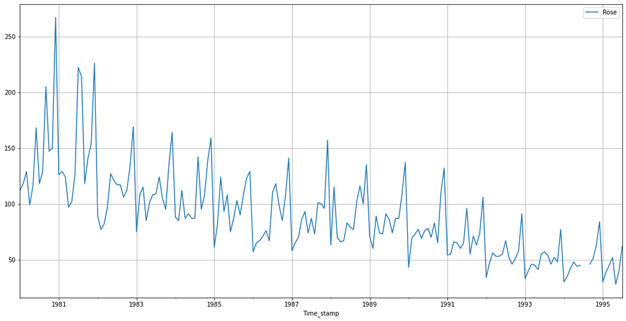

```python
#Plot the time series to understand the behaviour of data

rcParams['figure.figsize'] = 18,9

rose_data.plot()
plt.grid()
plt.show()
```

It is clearly visible that dataset has decreasing seasonality and trend. Also we can see that the year 1994 has the missing data

Now first we have to treat the missing observations in the dataset

We are using interpolation method to treat the missing observations. This interpolation method is to use a spline to connect the values. Using a spline interpolation requires you specify the order (number of terms in the polynomial). In our case, an order of 1 is just fine.

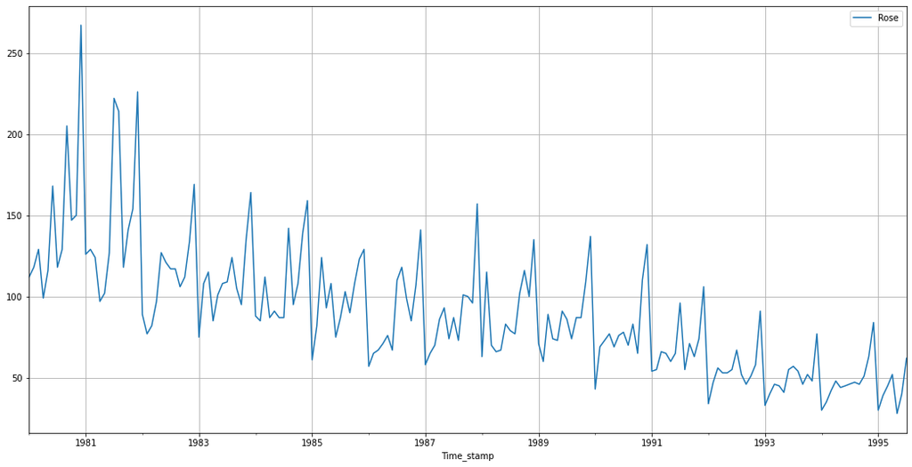

```python
rose_data = rose_data.interpolate(method='spline',order=1)

#re-plotting

rose_data.plot()
plt.grid()
plt.show()
```

Now we can see there are no missing points observed in the above plot.

### 2. Perform appropriate Exploratory Data Analysis to understand the data and also perform decomposition.

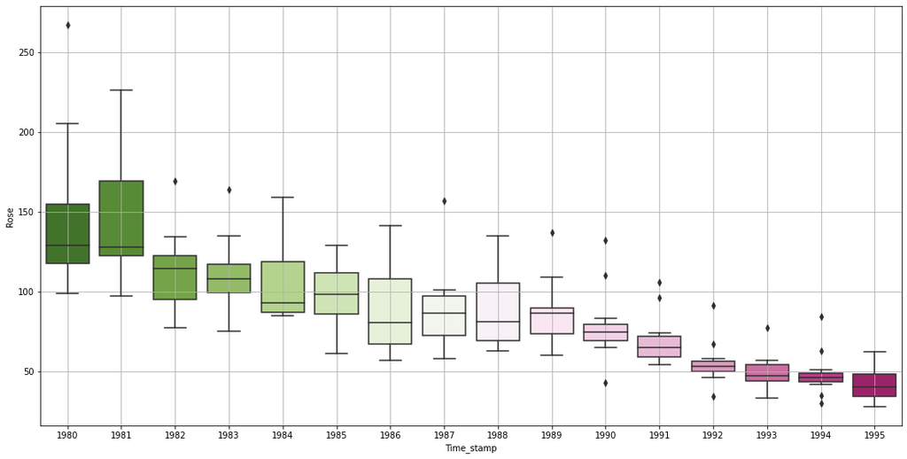

```python
#Building a yearly boxplot

sns.boxplot(x = rose_data.index.year, y = rose_data['Rose'], palette='PiYG_r')

plt.grid()
plt.show()
```

Fall in trend is clearly visible from yearly plot. Now let's see monthly plot.

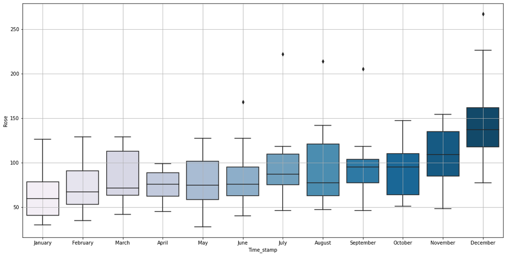

```python
#now let's look at the monthly boxplot

sns.boxplot(x = rose_data.index.month_name(), y = rose_data['Rose'], palette='PuBu')

plt.grid()
plt.show()
```

In monthly plot, the trend is growing.

```python
#Also by using pivot table with respect to sales, we can get some insights

sales_monthwise_per_year = pd.pivot_table(rose_data, values = 'Rose',
                                 columns = rose_data.index.month_name(),
                                 index = rose_data.index.year)

sales_monthwise_per_year
```

| Time_stamp | April | August | December | February | January | July | June | March | May | November | October | September |
| --- | --- | --- | --- | --- | --- | --- | --- | --- | --- | --- | --- | --- |
| 1980 | 99.0 | 129.000000 | 267.0 | 118.0 | 112.0 | 118.000000 | 168.0 | 129.0 | 116.0 | 150.0 | 147.0 | 205.0 |
| 1981 | 97.0 | 214.000000 | 226.0 | 129.0 | 126.0 | 222.000000 | 127.0 | 124.0 | 102.0 | 154.0 | 141.0 | 118.0 |
| 1982 | 97.0 | 117.000000 | 169.0 | 77.0 | 89.0 | 117.000000 | 121.0 | 82.0 | 127.0 | 134.0 | 112.0 | 106.0 |
| 1983 | 85.0 | 124.000000 | 164.0 | 108.0 | 75.0 | 109.000000 | 108.0 | 115.0 | 101.0 | 135.0 | 95.0 | 105.0 |
| 1984 | 87.0 | 142.000000 | 159.0 | 85.0 | 88.0 | 87.000000 | 87.0 | 112.0 | 91.0 | 139.0 | 108.0 | 95.0 |
| 1985 | 93.0 | 103.000000 | 129.0 | 82.0 | 61.0 | 87.000000 | 75.0 | 124.0 | 108.0 | 123.0 | 108.0 | 90.0 |
| 1986 | 71.0 | 118.000000 | 141.0 | 65.0 | 57.0 | 110.000000 | 67.0 | 67.0 | 76.0 | 107.0 | 85.0 | 99.0 |
| 1987 | 86.0 | 73.000000 | 157.0 | 65.0 | 58.0 | 87.000000 | 74.0 | 70.0 | 93.0 | 96.0 | 100.0 | 101.0 |
| 1988 | 66.0 | 77.000000 | 135.0 | 115.0 | 63.0 | 79.000000 | 83.0 | 70.0 | 67.0 | 100.0 | 116.0 | 102.0 |
| 1989 | 74.0 | 74.000000 | 137.0 | 60.0 | 71.0 | 86.000000 | 91.0 | 89.0 | 73.0 | 109.0 | 87.0 | 87.0 |
| 1990 | 77.0 | 70.000000 | 132.0 | 69.0 | 43.0 | 78.000000 | 76.0 | 73.0 | 69.0 | 110.0 | 65.0 | 83.0 |
| 1991 | 65.0 | 55.000000 | 106.0 | 55.0 | 54.0 | 96.000000 | 65.0 | 66.0 | 60.0 | 74.0 | 63.0 | 71.0 |
| 1992 | 53.0 | 52.000000 | 91.0 | 47.0 | 34.0 | 67.000000 | 55.0 | 56.0 | 53.0 | 58.0 | 51.0 | 46.0 |
| 1993 | 45.0 | 54.000000 | 77.0 | 40.0 | 33.0 | 57.000000 | 55.0 | 46.0 | 41.0 | 48.0 | 52.0 | 46.0 |
| 1994 | 48.0 | 47.221907 | 84.0 | 35.0 | 30.0 | 46.155493 | 45.0 | 42.0 | 44.0 | 63.0 | 51.0 | 46.0 |
| 1995 | 52.0 | NaN | NaN | 39.0 | 30.0 | 62.000000 | 40.0 | 45.0 | 28.0 | NaN | NaN | NaN |

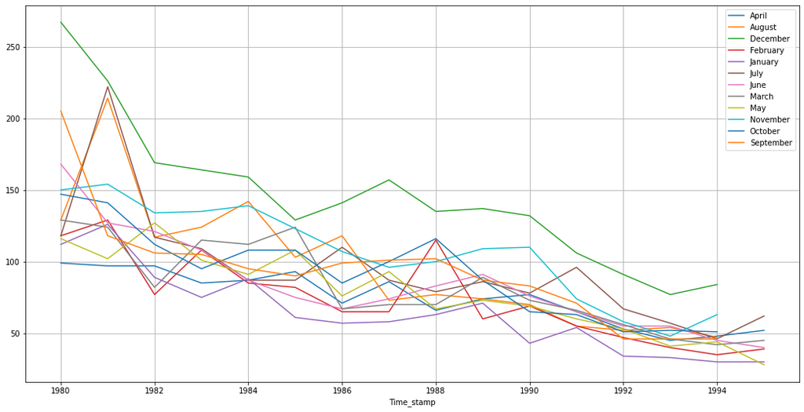

```python
#Now let's look at the plot of the above data monthwise

sales_monthwise_per_year.plot()

plt.grid()
plt.legend(loc='best')
plt.show()
```

#### From the above plot, every year the sales in December month(represented by green line) are higher than other months.

```python
#Decomposing the time series

#Importing seasonal_decompose from statsmodels.tsa.seasonal

from statsmodels.tsa.seasonal import seasonal_decompose #Decompose Timeseries
```

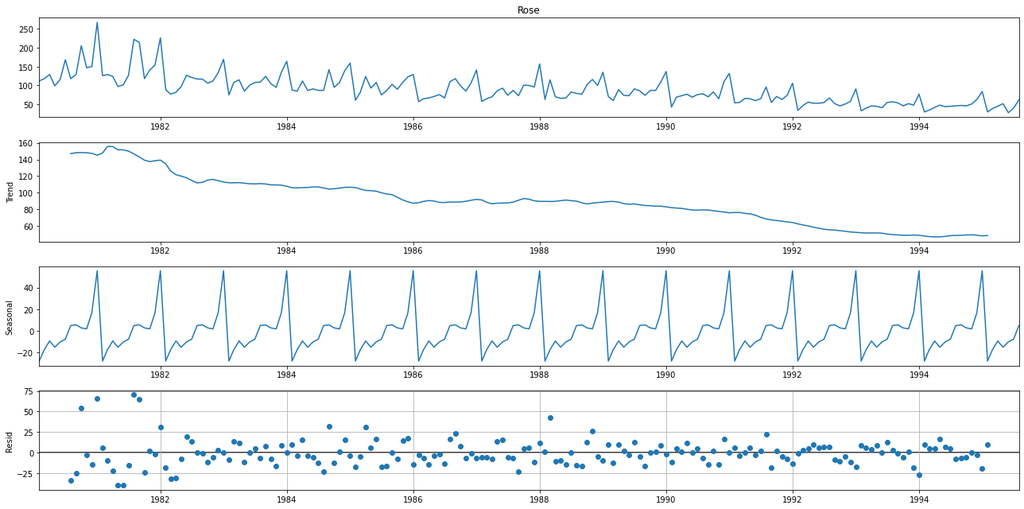

```python
# Let's first do the Additive decomposition:

add_decomposition = seasonal_decompose(rose_data['Rose'], model = 'additive')

#plotting
add_decomposition.plot();
plt.grid()
plt.show()
```

From the above plot we can clearly say that residual showing some patterns in the data, but trend and seasonality has no growth over the time.

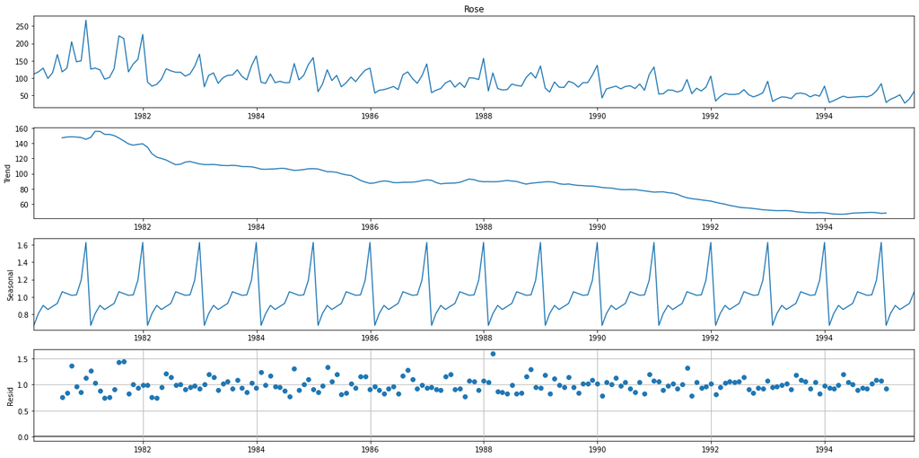

```python
#let's now look at the Multiplicative decomposition

mul_decomposition = seasonal_decompose(rose_data['Rose'], model = 'multiplicative')

mul_decomposition.plot();

plt.grid()
plt.show()
```

In the multiplicative model, residual still showing some patterns, so we will go with additive model.

### 3. Split the data into training and test. The test data should start in 1991.

```python
#let's split the data as per given condition

train = rose_data[rose_data.index.year < 1991]
test = rose_data[rose_data.index.year >= 1991]
```

```python
#checking tail of the train set and head of the test set

train.tail()
```

| Time_stamp | Rose |
| --- | --- |
| 1990-08-31 | 70.0 |
| 1990-09-30 | 83.0 |
| 1990-10-31 | 65.0 |
| 1990-11-30 | 110.0 |
| 1990-12-31 | 132.0 |

```python
test.head()
```

| Time_stamp | Rose |
| --- | --- |
| 1991-01-31 | 54.0 |
| 1991-02-28 | 55.0 |
| 1991-03-31 | 66.0 |
| 1991-04-30 | 65.0 |
| 1991-05-31 | 60.0 |

```python
test.tail()
```

| Time_stamp | Rose |
| --- | --- |
| 1995-03-31 | 45.0 |
| 1995-04-30 | 52.0 |
| 1995-05-31 | 28.0 |
| 1995-06-30 | 40.0 |
| 1995-07-31 | 62.0 |

We can see that the train set has the records up to 1990 and from 1991 test set holds the records up to 1995.

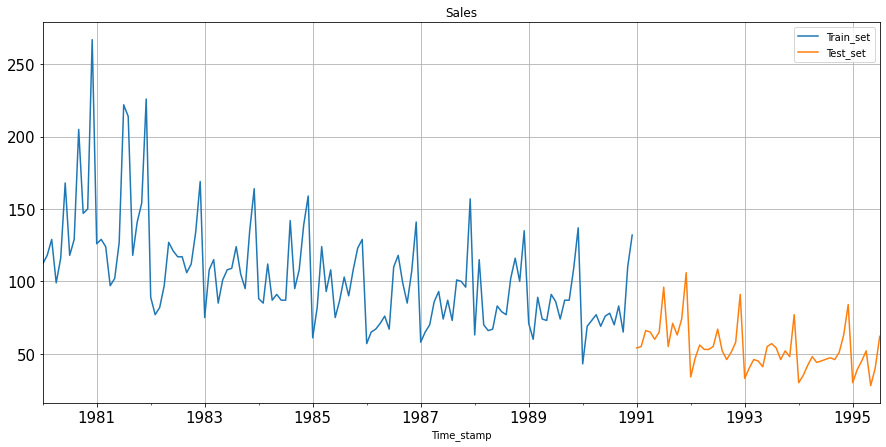

```python
#now let' look at the plot for train and test set

train['Rose'].plot(figsize = (15,7), fontsize = 15)
test['Rose'].plot(figsize = (15,7), fontsize = 15)
plt.grid()
plt.legend(['Train_set','Test_set'])
plt.title('Sales')
plt.show()
```

### 4. Build various exponential smoothing models on the training data and evaluate the model using RMSE on the test data. Other models such as regression,naïve forecast models, simple average models etc. should also be built on the training data and check the performance on the test data using RMSE.

#### Building Linear Regression Model:

```python
#modifying the train set before fitting into the model

train_time = [i+1 for i in range(len(train))]
test_time = [i+133 for i in range(len(test))]
print('Time instance for train set', '\n',train_time)
print('Time instance for test set', '\n',test_time)
```

```
Time instance for train set
 [1, 2, 3, 4, 5, 6, 7, 8, 9, 10, 11, 12, 13, 14, 15, 16, 17, 18, 19, 20, 21, 22, 23, 24, 25, 26, 27, 28, 29, 30, 31, 32, 33, 34, 35, 36, 37, 38, 39, 40, 41, 42, 43, 44, 45, 46, 47, 48, 49, 50, 51, 52, 53, 54, 55, 56, 57, 58, 59, 60, 61, 62, 63, 64, 65, 66, 67, 68, 69, 70, 71, 72, 73, 74, 75, 76, 77,…
Time instance for test set
 [133, 134, 135, 136, 137, 138, 139, 140, 141, 142, 143, 144, 145, 146, 147, 148, 149, 150, 151, 152, 153, 154, 155, 156, 157, 158, 159, 160, 161, 162, 163, 164, 165, 166, 167, 168, 169, 170, 171, 172, 173, 174, 175, 176, 177, 178, 179, 180, 181, 182, 183, 184, 185, 186, 187]
```

```python
#copying the train and test set for further analysis

LR_train = train.copy()
LR_test = test.copy()
```

```python
#now creating an new columns name time_instance and test_instance and putting the values of trainTime and test_time
LR_train['time_instance'] = train_time
LR_test['time_instance'] = test_time
```

```python
#let's check now

LR_train.head()
```

| Time_stamp | Rose | time_instance |
| --- | --- | --- |
| 1980-01-31 | 112.0 | 1 |
| 1980-02-29 | 118.0 | 2 |
| 1980-03-31 | 129.0 | 3 |
| 1980-04-30 | 99.0 | 4 |
| 1980-05-31 | 116.0 | 5 |

```python
LR_test.head()
```

| Time_stamp | Rose | time_instance |
| --- | --- | --- |
| 1991-01-31 | 54.0 | 133 |
| 1991-02-28 | 55.0 | 134 |
| 1991-03-31 | 66.0 | 135 |
| 1991-04-30 | 65.0 | 136 |
| 1991-05-31 | 60.0 | 137 |

```python
print(LR_train.shape)
print(LR_test.shape)
```

```
(132, 2)
(55, 2)
```

```python
#now, let's import the linearRegression package and fitting the train set

from sklearn.linear_model import LinearRegression

LR = LinearRegression()

LR.fit(LR_train[['time_instance']],LR_train['Rose'].values)
```

```
LinearRegression()
```

```python
#Now, checking the predictions on test set

LR_test_predict = LR.predict(LR_test[['time_instance']])

#Now, adding one more column for 'Regression_on_time'  in test

LR_test['Regression_on_time'] = LR_test_predict
```

```python
LR_test.head()
```

| Time_stamp | Rose | time_instance | Regression_on_time |
| --- | --- | --- | --- |
| 1991-01-31 | 54.0 | 133 | 72.063266 |
| 1991-02-28 | 55.0 | 134 | 71.568888 |
| 1991-03-31 | 66.0 | 135 | 71.074511 |
| 1991-04-30 | 65.0 | 136 | 70.580133 |
| 1991-05-31 | 60.0 | 137 | 70.085755 |

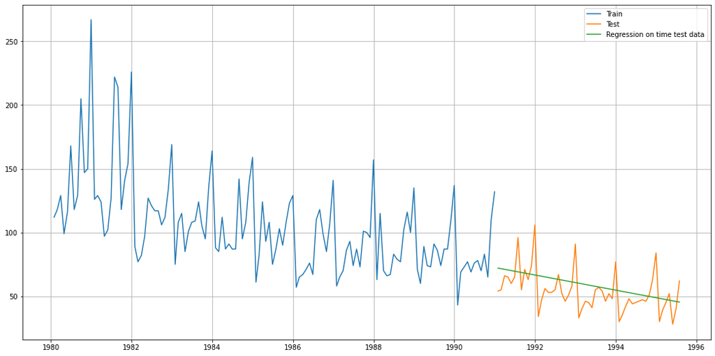

```python
#Plotting

plt.plot(train['Rose'],label = 'Train')
plt.plot(test['Rose'], label = 'Test')
plt.plot(LR_test['Regression_on_time'], label = 'Regression on time test data')

plt.legend(loc = 'best')
plt.grid()
```

```python
#now, let's calculate the RMSE value on test data

from sklearn import metrics

#RMSE on test data
RMSE_LR_test = metrics.mean_squared_error(test['Rose'],LR_test_predict,squared=False)
print("RMSE for regression forecast on test data is%3.3f" %(RMSE_LR_test))


resultsDf = pd.DataFrame({'Test RMSE': [RMSE_LR_test]},index=['RegressionOnTime'])
resultsDf
```

```
RMSE for regression forecast on test data is15.255
```

|  | Test RMSE |
| --- | --- |
| RegressionOnTime | 15.255435 |

#### Naive model:

```python
NM_train = train.copy()
NM_test = test.copy()
```

```python
#now we will create the new column in the NM_test set and checking the head
NM_test['naive'] = np.asarray(train['Rose'])[len(np.asarray(train['Rose']))-1]
NM_test['naive'].head()
```

```
Time_stamp
1991-01-31    132.0
1991-02-28    132.0
1991-03-31    132.0
1991-04-30    132.0
1991-05-31    132.0
Name: naive, dtype: float64
```

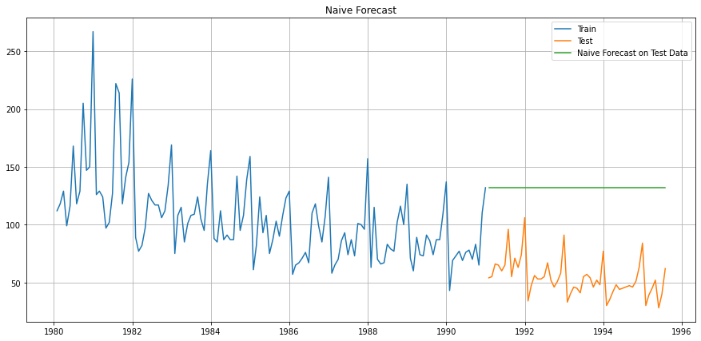

```python
#Plotting

plt.figure(figsize=(15,7))

plt.plot(NM_train['Rose'], label='Train')
plt.plot(test['Rose'], label='Test')
plt.plot(NM_test['naive'], label='Naive Forecast on Test Data')
plt.legend(loc='best')
plt.title("Naive Forecast")
plt.grid()
plt.show()
```

```python
#let's check RMSE value on test data

#RMSE on test set
RMSE_NM_test = metrics.mean_squared_error(test['Rose'],NM_test['naive'],squared=False)
print("RMSE for naive model forecast on test data is %3.3f" %(RMSE_NM_test))
```

```
RMSE for naive model forecast on test data is 79.672
```

#### Simple Average Model:

```python
#copying for further evaluation
SA_train = train.copy()
SA_test = test.copy()
```

```python
#In Simple Average model we will take the average of the training values and then will forecast using it.

SA_test['mean_forecast'] = train['Rose'].mean()

SA_test.head()
```

| Time_stamp | Rose | mean_forecast |
| --- | --- | --- |
| 1991-01-31 | 54.0 | 104.939394 |
| 1991-02-28 | 55.0 | 104.939394 |
| 1991-03-31 | 66.0 | 104.939394 |
| 1991-04-30 | 65.0 | 104.939394 |
| 1991-05-31 | 60.0 | 104.939394 |

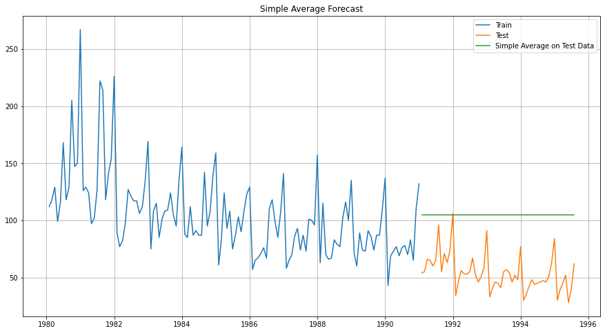

```python
#Plotting

plt.figure(figsize=(15,8))
plt.plot(SA_train['Rose'], label='Train')
plt.plot(SA_test['Rose'], label='Test')
plt.plot(SA_test['mean_forecast'], label='Simple Average on Test Data')
plt.legend(loc='best')
plt.title("Simple Average Forecast")
plt.grid();
```

```python
#Calculating RMSE value on test data

RMSE_SA_test = metrics.mean_squared_error(test['Rose'],SA_test['mean_forecast'],squared=False)
```

```python
print("RMSE for Simple average forecast on test data is %3.3f" %(RMSE_SA_test))
```

```
RMSE for Simple average forecast on test data is 53.413
```

#### Till now, regression forecast is best with having the lowest rmse value of 15.25

#### Building Moving Average Model:

```python
#For this model, we need to calculate moving averages for different intervals.

#The best interval can be determined by the maximum accuracy with the minimum error.

mov_avg = rose_data.copy()
```

```python
#Now, for this model, we'll calculate rolling means for different intervals.

#let's calculate this:

mov_avg['Trailing_2'] = mov_avg['Rose'].rolling(2).mean()
mov_avg['Trailing_4'] = mov_avg['Rose'].rolling(4).mean()
mov_avg['Trailing_6'] = mov_avg['Rose'].rolling(6).mean()
mov_avg['Trailing_9'] = mov_avg['Rose'].rolling(9).mean()
```

```python
mov_avg.head()
```

| Time_stamp | Rose | Trailing_2 | Trailing_4 | Trailing_6 | Trailing_9 |
| --- | --- | --- | --- | --- | --- |
| 1980-01-31 | 112.0 | NaN | NaN | NaN | NaN |
| 1980-02-29 | 118.0 | 115.0 | NaN | NaN | NaN |
| 1980-03-31 | 129.0 | 123.5 | NaN | NaN | NaN |
| 1980-04-30 | 99.0 | 114.0 | 114.5 | NaN | NaN |
| 1980-05-31 | 116.0 | 107.5 | 115.5 | NaN | NaN |

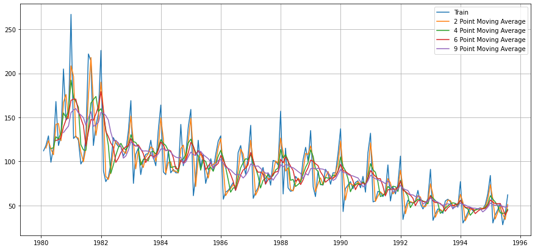

```python
#Plotting

plt.figure(figsize=(15,7))
plt.plot(mov_avg['Rose'], label='Train')
plt.plot(mov_avg['Trailing_2'], label='2 Point Moving Average')
plt.plot(mov_avg['Trailing_4'], label='4 Point Moving Average')
plt.plot(mov_avg['Trailing_6'],label = '6 Point Moving Average')
plt.plot(mov_avg['Trailing_9'],label = '9 Point Moving Average')
plt.legend(loc = 'best')
plt.grid()
plt.show()
```

```python
# Now we will split the data and create the train and test set

trailing_MA_train= mov_avg[0:int(len(mov_avg)*0.709677)]
trailing_MA_test = mov_avg[int(len(mov_avg)*0.709677):]
```

```python
#Now, let's check the count for trailing 2, trailing 4, trailing 6 and trailing 9 moving averages for train set

trailing_MA_train.count()
```

```
Rose          132
Trailing_2    131
Trailing_4    129
Trailing_6    127
Trailing_9    124
dtype: int64
```

```python
#Now, let's check the count for trailing 2, trailing 4, trailing 6 and trailing 9 moving averages for test set

trailing_MA_test.count()
```

```
Rose          55
Trailing_2    55
Trailing_4    55
Trailing_6    55
Trailing_9    55
dtype: int64
```

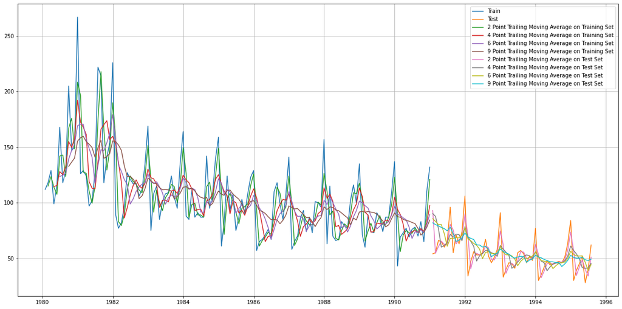

```python
#Plotting

plt.figure(figsize=(20,10))
plt.plot(trailing_MA_train['Rose'], label='Train')
plt.plot(trailing_MA_test['Rose'], label='Test')

plt.plot(trailing_MA_train['Trailing_2'],label='2 Point Trailing Moving Average on Training Set')
plt.plot(trailing_MA_train['Trailing_4'],label='4 Point Trailing Moving Average on Training Set')
plt.plot(trailing_MA_train['Trailing_6'],label= '6 Point Trailing Moving Average on Training Set')
plt.plot(trailing_MA_train['Trailing_9'],label= '9 Point Trailing Moving Average on Training Set')

plt.plot(trailing_MA_test['Trailing_2'],label='2 Point Trailing Moving Average on Test Set')
plt.plot(trailing_MA_test['Trailing_4'],label='4 Point Trailing Moving Average on Test Set')
plt.plot(trailing_MA_test['Trailing_6'],label= '6 Point Trailing Moving Average on Test Set')
plt.plot(trailing_MA_test['Trailing_9'],label= '9 Point Trailing Moving Average on Test Set')
plt.legend(loc = 'best')
plt.grid()
plt.show()
```

```python
#Evaluation on test data for RMSE values of trailing 2,4,6 and 9

#RMSE for Test Data :2 point Trailing MA

RMSE_MA_test_2 = metrics.mean_squared_error(test['Rose'],trailing_MA_test['Trailing_2'],squared=False)
print("For 2 point Moving Average Model forecast on the Training Data,  RMSE value is %3.3f" %(RMSE_MA_test_2))

#RMSE for Test Data :4 point Trailing MA

RMSE_MA_test_4 = metrics.mean_squared_error(test['Rose'],trailing_MA_test['Trailing_4'],squared=False)
print("For 4 point Moving Average Model forecast on the Training Data,  RMSE value is %3.3f" %(RMSE_MA_test_4))

#RMSE for Test Data :6 point Trailing MA

RMSE_MA_test_6 = metrics.mean_squared_error(test['Rose'],trailing_MA_test['Trailing_6'],squared=False)
print("For 6 point Moving Average Model forecast on the Training Data,  RMSE value is %3.3f" %(RMSE_MA_test_6))

#RMSE for Test Data :9 point Trailing MA

RMSE_MA_test_9 = metrics.mean_squared_error(test['Rose'],trailing_MA_test['Trailing_9'],squared=False)
print("For 9 point Moving Average Model forecast on the Training Data,  RMSE value is %3.3f " %(RMSE_MA_test_9))
```

```
For 2 point Moving Average Model forecast on the Training Data,  RMSE value is 11.530
For 4 point Moving Average Model forecast on the Training Data,  RMSE value is 14.444
For 6 point Moving Average Model forecast on the Training Data,  RMSE value is 14.555
For 9 point Moving Average Model forecast on the Training Data,  RMSE value is 14.721
```

#### From the above calculations, we can say that till now the best model seems to be 2 point moving average forecast model, with the lowest rmse value of 11.530